# 📌 Objetivo

1. Descrever a lógica pela qual se pode concluir que alguém consegue distinguir entre duas coisas
2. Indicar se a atribuição aleatória garante que todas as fontes não controladas de variação sejam iguais
3. Definir precisamente qual é a probabilidade calculada para chegar à conclusão de que uma diferença não se deve ao acaso
4. Distinguir entre a probabilidade de um evento e a probabilidade de um estado do mundo
5. Definir "hipótese nula"
6. Ser capaz de determinar a hipótese nula a partir da descrição de um experimento
7. Definir "hipótese alternativa"

# 🎯 Conceito

O teste de hipóteses é uma técnica estatística que usamos para tomar decisões com base em dados amostrais. A ideia central é verificar se uma hipótese sobre um parâmetro populacional pode ser rejeitada ou não, com base nos dados disponíveis.

É uma ferramenta estatística usada para verificar se uma afirmação sobre um parâmetro populacional (como a média ou a proporção) é estatisticamente compatível com os dados que coletamos de uma amostra.

# 🧠 História

**A Dama que Provava o Chá (The Lady Tasting Tea)**

Fisher contou a história de uma senhora que afirmava ser capaz de distinguir se o leite foi colocado antes ou depois do chá em uma xícara, apenas pelo sabor.

Fisher, sendo um estatístico cético, decidiu testar a hipótese da dama com um experimento:

Foram preparadas 8 xícaras de chá:

- 4 com leite colocado antes do chá
- 4 com leite colocado depois do chá

As xícaras foram apresentadas em ordem aleatória. A dama precisava identificar quais 4 xícaras eram de cada tipo.

🧪 O Teste de Hipóteses:

🧩 Hipóteses: H₀ (Hipótese nula): A senhora está apenas adivinhando (não tem habilidade real). H₁ (Hipótese alternativa): A senhora realmente consegue distinguir a ordem do leite e do chá.

🎯 Como funciona? Fisher sabia que, por puro acaso, a chance da senhora acertar as 4 xícaras exatamente seria baixa. Se isso acontecesse, ele teria evidência contra H₀.

🎲 A Probabilidade e o P-valor:

No teste de Fisher: Se a dama acertasse todas as 4 corretamente, o p-valor seria muito baixo (aproximadamente 1 em 70). Isso significaria que seria muito improvável ela ter acertado por sorte — e, portanto, haveria evidência a favor de H₁.

📌 Por que esse exemplo é famoso? Porque ele mostra perfeitamente o que é um teste de hipótese:

- Formulamos uma suposição nula (H₀)
- Realizamos um experimento
- Calculamos a probabilidade do resultado se H₀ fosse verdade
- Se essa probabilidade (p-valor) for muito baixa, rejeitamos H₀

# 🍃 As Hipóteses

Toda vez que temos uma afirmação a comprovar, precisamos traduzir essa afirmação em duas hipóteses: a Hipótese Nula (H0) e a Hipótese Alternativa (Ha), em que:

Uma hipótese nula (H0) é uma hipótese estatística que contém uma afirmação de igualdade, tal como ≤, = ou ≥.

A hipótese alternativa (Ha) é o complemento da hipótese nula. É uma afirmação que é aceita como verdadeira se H0 for falsa e contém uma declaração de desigualdade estrita, tal como <, ≠ ou >.

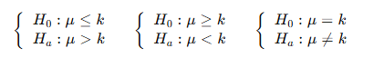

🩺 Exemplo 1 – Uma secretaria de saúde afirma que 75% da população adulta foi vacinada contra gripe este ano. Um pesquisador coleta uma amostra aleatória de 400 adultos e encontra 280 vacinados. Será que a taxa de vacinação é mesmo 75%?

H₀: p = 0,75

Hₐ: p ≠ 0,75

Etapa Ação

- 1 Especifique H₀ e Hₐ
- 2 Defina o nível de significância (ex: 0,05)
- 3 Escolha o teste adequado (ex: z para proporções, t para médias)
- 4 Calcule a estatística do teste e o p-valor
- 5 Compare com α e interprete o resultado

# ⚡ Premissa da Hipótese Nula

A hipótese nula, representada por H₀, é a afirmação inicial que fazemos sobre um parâmetro populacional, como a média, proporção ou desvio padrão.

Ela pressupõe que não há efeito, não há diferença, não há mudança.

- 📌 É o “ponto de partida” do teste estatístico.
- 📌 É a hipótese que tentamos refutar com dados da amostra.

🧠 Exemplos em linguagem simples:

- “A média de pressão arterial com o novo remédio é igual à do remédio antigo.”
- “A proporção de pacientes com complicações não mudou em relação ao ano passado.”
- “A campanha de saúde não impactou o número de doações de sangue.”

Todos esses exemplos partem da suposição de que nada mudou, ou seja, que qualquer diferença observada é apenas fruto da variação natural (erro amostral).

🧪 Exemplo prático em saúde: “O hospital afirma que a taxa de infecção é de 8%. Um novo protocolo foi implantado. Queremos saber se houve impacto.”

H₀: p = 0,08 (A taxa de infecção ainda é 8%)

Hₐ: p ≠ 0,08 (A taxa mudou – pode ter aumentado ou diminuído)

Nesse cenário, a H₀ é conservadora: assume que nada mudou até que os dados provem o contrário.

🛡️ Por que começamos com a hipótese nula? Porque ela funciona como "presunção de inocência":

👉 A hipótese nula só é rejeitada com evidência forte o suficiente (ex: p-valor < 0,05). 👉 Se não houver evidência suficiente, mantemos H₀ (não rejeitamos).

Assim como um réu só é condenado com provas suficientes, uma hipótese nula só é rejeitada quando os dados tornam sua validade improvável.

🔁 H₀ pode ser:

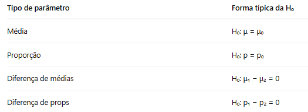

# ✅ Exemplo

Imagine que um pesquisador está estudando os níveis médios de colesterol LDL em uma população de pacientes adultos. No ano passado, a média populacional registrada era de 130 mg/dL. Neste ano, com o objetivo de verificar se houve alguma mudança, o pesquisador seleciona aleatoriamente 25 pacientes para medir seus níveis atuais de colesterol LDL.

**Dados da amostra**

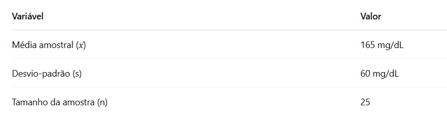

Logo, o pesquisador decide fazer um teste de hipótese. Para isso ele traça as 2 hipóteses necessárias

✳️ Formulação das Hipóteses

- Hipótese nula (H₀): A média do colesterol LDL na população permanece igual a 130 mg/dL.
- Hipótese alternativa (H₁): A média não é igual a 130 mg/dL.

Ou seja:

H₀: μ = 130

H₁: μ ≠ 130

Para responder a essa pergunta, simulamos a distribuição amostral com base na suposição de que a média populacional não mudou e continua sendo 130 mg/dL.

O grande ponto aqui é: **todos os testes de hipótese começam assumindo que a hipótese nula está correta**. Não sabemos se de fato ela está, mas precisamos de um ponto de partida — e ele é: suponha que H₀ está certa.

A partir da suposição de que a média continua sendo 130 mg/dL, podemos gerar a distribuição de todas as médias possíveis (caso muitas amostras de 25 pacientes fossem coletadas). Essa distribuição nos permite ver o quão improvável seria obter uma média amostral como 165 mg/dL se a média real da população ainda fosse 130 mg/dL.

Imagine uma curva normal centrada em 130 mg/dL. Podemos colocar a média observada (165 mg/dL) nesse gráfico. Se ela estiver muito distante do centro da curva, indicará que tal média seria muito improvável — sugerindo que H₀ pode estar errada.

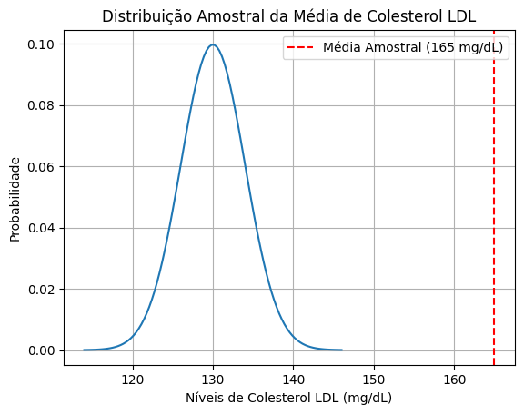

```
z-score: 8.75
p-valor: 0.0
```

```python
import numpy as np
import matplotlib.pyplot as plt
from scipy.stats import norm

# Dados do problema
media_populacional = 130  # mg/dL
media_amostral = 165  # mg/dL
tamanho_amostra = 25
desvio_padrao_populacional = 20 # exemplo

# Calculando o desvio padrão da média amostral
desvio_padrao_media_amostral = desvio_padrao_populacional / np.sqrt(tamanho_amostra)

# Criando a curva normal
x = np.linspace(media_populacional - 4 * desvio_padrao_media_amostral, media_populacional + 4 * desvio_padrao_media_amostral, 100)
y = norm.pdf(x, loc=media_populacional, scale=desvio_padrao_media_amostral)

# Plotando a curva normal
plt.plot(x, y)

# Marcando a média amostral no gráfico
plt.axvline(x=media_amostral, color='red', linestyle='--', label='Média Amostral (165 mg/dL)')

# Configurando o gráfico
plt.title('Distribuição Amostral da Média de Colesterol LDL')
plt.xlabel('Níveis de Colesterol LDL (mg/dL)')
plt.ylabel('Probabilidade')
plt.legend()
plt.grid(True)

# Exibindo o gráfico
plt.show()

# Calculando o p-valor (exemplo)
z_score = (media_amostral - media_populacional) / desvio_padrao_media_amostral
p_valor = 2 * (1 - norm.cdf(abs(z_score))) # teste bilateral

print(f"z-score: {z_score}")
print(f"p-valor: {p_valor}")
```

No entanto, não existe um ponto exato na curva que indique quando a hipótese nula deve ser rejeitada. O que há é uma região de cauda da distribuição que nos permite calcular a probabilidade de observar um valor tão extremo quanto 165 se H₀ for verdadeira. Essa probabilidade é chamada de p-valor — e se for pequena o suficiente (menor que 0,05, por exemplo), rejeitamos H₀.

🔍 Conclusão: A hipótese nula funciona como a teoria padrão: partimos do pressuposto de que nada mudou. A partir da evidência da amostra (neste caso, uma média de 165 mg/dL), utilizamos a estatística inferencial para decidir se devemos manter ou rejeitar essa hipótese inicial. Esse processo nos ajuda a tomar decisões mais objetivas e baseadas em probabilidade — o que é essencial em análises científicas e clínicas na saúde.

# 🔍 O que é o Valor-P?

Definição correta: O valor-p é a probabilidade de observar um resultado igual ou mais extremo que o obtido, dado que a hipótese nula seja verdadeira.

Matematicamente, é representado como Prob(X ≥ x | H₀)

# ❌ Erros comuns de interpretação (Misconceptions)

> "O valor-p é provavelmente o índice mais onipresente e, ao mesmo tempo, o mais mal compreendido, mal interpretado e ocasionalmente mal calculado em toda a pesquisa biomédica." Garcia-Berthou E, Alcaraz C. Incongruence between test statistics and P values in medical papers. BMC Medical Research Methodology, volume 4, página 13, ano 2004.

**Se o p-valor é pequeno, então o resultado não é devido ao acaso. Ou se o p-valor é grande, o resultado pode ser apenas acaso.** É verdade que o p-valor mede a compatibilidade dos dados com a hipótese nula — e a hipótese nula geralmente assume que as diferenças observadas seriam "por acaso", ou melhor, devido à variabilidade natural dos dados (Algumas amostras, por pura sorte, podem gerar valores bastante diferentes, mas isso não prova que houve mudança na população). Mas o p-valor não mede diretamente: Se o acaso foi a única explicação. Se outra hipótese alternativa é verdadeira. Se o estudo foi bem desenhado, livre de vieses, etc. Ou seja: "não é só o acaso que pode explicar os resultados". Pode ser erro de medição. Pode ser viés de seleção. Pode ser confusão por variáveis não controladas. Pode ser má condução do experimento. Pode ser que o efeito real seja pequeno e o experimento não teve poder estatístico para discriminar.

**P <= 0,05 significa que H₀ tem só 5% de chance de ser verdadeira**: Falso. Esta é uma das concepções errôneas mais difundidas. O valor P é calculado assumindo que a hipótese nula é verdadeira e, portanto, não pode ser a probabilidade de a hipótese nula ser falsa.

**P > 0,05 prova que não há diferença**: Falso. Apenas indica que não há evidência suficiente para rejeitar H₀. Na verdade, quer dizer apenas que você não encontrou evidência suficiente para afirmar que existe uma diferença. Pode ser que a diferença realmente exista, mas o seu estudo não teve poder estatístico suficiente para detectá-la (ex.: amostra pequena, alta variabilidade) ou que a diferença seja pequena e dentro da margem de erro natural. Ainda assim, mesmo quando o resultado é "não significativo", o melhor resumo do que os dados mostram é o efeito observado (ou seja, o que foi medido no seu estudo), não a hipótese nula ("não existe diferença").

**Estudos com p <= 0,05 e p > 0,05 são conflitantes**: Falso. Um estudo pode ter p < 0,05 e o outro p > 0,05 mesmo que o efeito observado (a diferença entre tratamentos) seja praticamente o mesmo. A única diferença pode ser o tamanho da amostra ou a precisão da medição. Isso porque estudos com amostras pequenas tendem a ter mais variabilidade nos resultados e intervalos de confiança maiores, de modo que então p-valor pode ser >0,05. Estudos com amostras grandes têm estimativas mais precisas e então p-valor pode cair para <0,05. A Conclusão correta é na verdade: Dois estudos só realmente entram em conflito se os seus intervalos de confiança quase não se sobrepõem — ou seja, se eles sugerem efeitos realmente diferentes entre si. Isso é medido formalmente por um teste de heterogeneidade.

**Mesmo p-valor implica mesmo grau de evidência**: Falso. Dois p-valores iguais podem vir de efeitos muito diferentes. Exemplo 1: Um estudo mostrou 3% de benefício (intervalo de confiança de 0% a 6%). Exemplo 2: Outro estudo mostrou 19% de benefício (intervalo de confiança de 0% a 38%). Ambos tiveram p = 0,05! Mas são cenários muito diferentes: Um efeito de 3% pode ser muito pequeno e até não clinicamente relevante. Um efeito de 19% é grande e pode ter grande importância clínica. Então, o p-valor sozinho não te diz a magnitude do efeito nem o quanto ele é importante para a prática clínica.

**"P <= 0,05 significa que observamos um dado que ocorreria apenas 5% das vezes se a hipótese nula fosse verdadeira.** Falso. O p-valor é a probabilidade de observar o dado obtido ou dados ainda mais extremos sob a hipótese nula. Então, não é só o dado exato que você observou que é considerado. O p-valor também inclui resultados que você nem viu, mas que seriam ainda mais discrepantes do que o seu resultado.

**P = 0,05 e P ≤ 0,05 significam a mesma coisa.** Falso. Embora o número 5% apareça em ambos os casos, há uma diferença de peso de evidência entre ter um p-valor exatamente 0,05 e ter um p-valor menor que 0,05 (por exemplo, 0,01). P = 0,05 está exatamente no limiar, ou seja, é o valor limite que ainda seria considerado significativo. P < 0,05 (por exemplo, p=0,01) indica uma evidência muito mais forte contra a hipótese nula. O problema é que, culturalmente, tratamos p=0,049 e p=0,051 como se fossem mundos completamente diferentes, e p=0,049 e p=0,01 como se fossem a mesma coisa — mas, na realidade, há muito mais evidência quando o p é bem menor. Só que, usando p-valor puro, fica muito difícil enxergar claramente essa diferença. Usando medidas bayesianas, como o fator de Bayes, essa diferença se torna quantitativamente evidente.

**P-valores devem ser sempre relatados como desigualdades ("P<0,01")**: Falso. Em um teste de hipótese clássico, você estabelece um limite de rejeição previamente (por exemplo, p <=0,05). Aí sim, faz sentido usar desigualdades, tipo: "O p-valor foi maior ou menor que 0,05?". Ou seja, P ≤ 0,05 (rejeita H₀) ou P > 0,05 (não rejeita H₀). Só nesse contexto, escrever p-valores como desigualdade faz sentido. Mas geralmente estamos interessados em quanto de evidência existe contra a hipótese nula; é por isso que usamos valores de P. Para esse propósito, importa se o valor de P é igual a 0,50, 0,06, 0,04 ou 0,00001. Para transmitir a força da evidência, o valor exato de P deve sempre ser relatado. Se uma desigualdade for usada para indicar apenas se a hipótese nula deve ser rejeitada ou não, isso só pode ser feito com um limiar pré-especificado, como 0,05. O limiar não pode depender do valor de P observado, ou seja, não podemos relatar “P < 0,01” se observarmos P = 0,008 e o limiar era 0,05. Não importa quão pequeno seja o valor de P, devemos relatar “P < 0,05” se esse era o limiar predefinido. Mas rejeitar ou não é raramente o único interesse. Muitos periódicos médicos exigem que valores de P muito pequenos (por exemplo, <0,001) sejam relatados como desigualdades como uma questão de estilo. Isso normalmente não é um grande problema, exceto em situações em que literalmente milhares de testes estatísticos foram realizados (como em experimentos genômicos), quando muitos valores de P muito pequenos podem ser gerados por acaso (p-hacking), e a distinção entre valores de P pequenos e extremamente pequenos se torna importante para conclusões apropriadas.

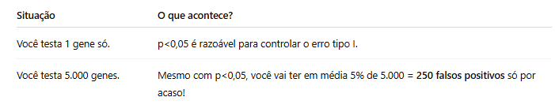

Então o p-valor de 0,04, 0,01 ou até 0,001 não garante que a descoberta seja real. Você precisa corrigir para múltiplas comparações (com métodos como Bonferroni, FDR, etc.) ou adotar uma visão Bayesiana.

Esse é o jeito bayesiano de pensar (diferente do frequentista): combina a evidência dos dados + o que já sabíamos ou supúnhamos antes.

**Deve-se usar p unilateral quando só interessa um lado**: Problemático porque insere vieses de julgamento sobre o que deveria ser evidência. Isso ocorre porque o efeito operacional do uso de um p-valor unilateral é aumentar a aparente força da evidência para um resultado, baseando-se em considerações que não vêm dos dados. Assim, o uso de um p-valor unilateral significa que o p-valor irá incorporar atitudes, crenças ou preferências do experimentador na avaliação da força da evidência. Se estamos interessados no p-valor como uma medida da força da evidência, isso não faz sentido. Se estamos interessados nas probabilidades de cometer erros tipo I ou tipo II, então considerar regiões de rejeição unilaterais ou bilaterais pode fazer sentido.

**Significância estatística é igual a importância clínica**: Falso. Ter um p-valor significativo (p < 0,05) não significa que a diferença encontrada seja clinicamente importante. Existem dois grandes problemas:

- O tamanho da diferença pode ser muito pequeno para ter relevância clínica. Exemplo: encontrar uma diferença de 1 mmHg na pressão arterial entre dois tratamentos anti-hipertensivos pode ser estatisticamente significativa, mas clinicamente irrelevante.
- O que está sendo medido (o "desfecho") pode não ser algo que importa clinicamente. Exemplos: Taxa de resposta de um tumor (redução do tamanho) não é o mesmo que aumento na sobrevida. Contagem de CD4 em pacientes HIV+ não é o mesmo que controle da doença clínica.

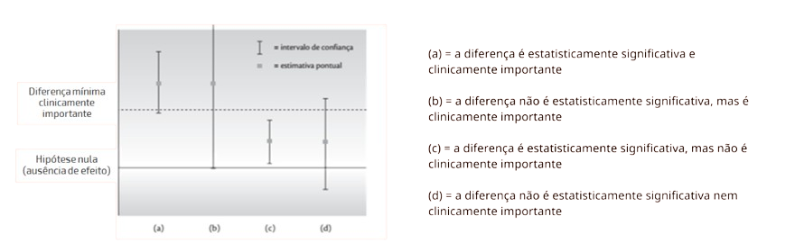

**Decisões clínicas/políticas devem ser baseadas só na significância**: Falso. É equivalente a dizer que a magnitude do efeito não é relevante, que apenas a evidência estatística de um único estudo é suficiente para uma conclusão científica, e que crenças e ações devem fluir diretamente dos resultados estatísticos. Precisamos considerar contexto, tamanho do efeito e plausibilidade teórica. Assim, a evidência de um dado estudo precisa ser combinada com aquela de trabalhos anteriores para gerar uma conclusão. Em algumas situações, uma conclusão cientificamente defensável pode ser que a hipótese nula ainda seja provavelmente verdadeira mesmo após um resultado significativo, e, em outras situações, um p-valor não significativo ainda pode levar a uma conclusão de que o tratamento funciona. Isso só pode ser feito formalmente através de abordagens bayesianas. Para justificar ações, precisamos incorporar: A seriedade dos erros que podem decorrer dessas ações, junto com a chance de que as conclusões estejam erradas.